# **에너지거래단가 실적분석 REPORT**

#### MSLEE(mosuklee@gmail.com)

#### 2019-02-03

### **1. 개 요**

본 Report는 한국전력거래소의 I-SMART 에서 제공하는 전력거래 단가 실적중 SMP의 가중치 평균을 Web Crawling이용하여 자료수집 및 분석을 하였으며, REC는 신재생원스톱 사업종별 통합포털의 현물시장 속보를 이용하여 현물시장에서 거래되는 REC의 단가 및 거래량을 분석하였습니다.

SMP자료는 2015년도부터 현재까지 월별 거래현황을 분석하여 나타내었으며, 최근 1주일간 시간대별 SMP의 거래가격등을 분석하였습니다. REC는 2016년 3월부터 현재까지 월별 거래현황을 분석하였으며, 거래단가의 허수를 검토/판단하기 위하여 거래량까지 그래프로 분석하여 나타내었습니다.

SMP의 경우 거래량을 전량 판매가 가능한 시스템으로 되어 있으나, 현물시장에서 REC의 경우 발전사인 구매자와 발전사업자인 판매자의 사이에서 거래가 이루어지므로 판매단가가 어느정도 유지되더라도 거래량이 적을 수 있으므로 특히 사업을 준비하거나 경제성분석을 하고자 하는 신중할 필요성이 있습니다.

PF사업의 경우 대부분 대규모 사업을 계획하고 있으므로 계약시장을 겨냥하여 사업성분석을 하여야 하므로 현물시장으로 단가를 분석할 경우 실제 거래시 문제가 될 수 있으므로 반드시 유사프로젝트의 장기 계약현황등을 분석한 후에 경제성분석을 하는 것이 좋습니다. 필자의 경험에서 볼때 현물시장가의 90% 미만대에서 가격이 형성되는 것을 볼 수 있었습니다.

### **2. SMP 실적분석**

```
[SMP(계통한계가격, System Marginal Price)]
SMP는 각 시간대별 수요를 충족시키기 위하여 발전이 할당된 발전기별 발전가격(변동비) 중 가장 비싼 값을 뜻합니다. 모든 발전기는 발전에 대한 대가로 동일하게 이 가격을 적용 받게 됩니다.
SMP가격은 한전에서 전기를 매입하는 가격으로 발전량에 비례하여 모든 사업자가 동일한 단가를 적용 받아 수익을 창출합니다.
```

#### **2.1 최근 일별 SMP 현황**

최근 1주일간의 시간대별 SMP 분석자료이며 각 일별 최대.최소.값을 분석하였으며, 일별 가중평균 값을 분석하였습니다.

| Hour | D-6 | D-5 | D-4 | D-3 | D-2 | D-1 | D-day |
| --- | --- | --- | --- | --- | --- | --- | --- |
| 1h | 109.29 | 113.02 | 109.54 | 111.96 | 106.95 | 107.31 | 114.31 |
| 2h | 108.57 | 113.33 | 108.91 | 110.16 | 106.81 | 108.41 | 109.11 |
| 3h | 100.41 | 106.61 | 110.5 | 107.05 | 107.86 | 107.27 | 109.11 |
| 4h | 99.27 | 106.5 | 106.42 | 107.05 | 105.12 | 108.55 | 102.4 |
| 5h | 107.08 | 108.1 | 108.21 | 107.05 | 106.28 | 106.97 | 100.18 |
| 6h | 108.52 | 109.64 | 109.68 | 107.05 | 106.28 | 106.21 | 100.18 |
| 7h | 106.97 | 109.64 | 109.68 | 109.36 | 108.57 | 109.38 | 100.18 |
| 8h | 111.91 | 113 | 113.1 | 116.16 | 111.63 | 106.54 | 98.68 |
| 9h | 115.42 | 115.39 | 116.04 | 116.45 | 112.76 | 107.37 | 90.13 |
| 10h | 116.2 | 115.39 | 116.03 | 116.45 | 116.16 | 106.52 | 82.6 |
| 11h | 116.18 | 114.74 | 114.22 | 116.03 | 112.76 | 109.38 | 81.85 |
| 12h | 115.21 | 114.67 | 113.66 | 115.07 | 112.76 | 109.38 | 68.38 |
| 13h | 110.86 | 109.29 | 109.43 | 110.62 | 108.08 | 102.6 | 61.72 |
| 14h | 113.35 | 112.17 | 111.91 | 112.23 | 108.08 | 102.6 | 61.72 |
| 15h | 113.35 | 112.68 | 113.44 | 112.23 | 108.08 | 102.6 | 61.72 |
| 16h | 114.38 | 112.68 | 113.89 | 113.93 | 108.08 | 102.6 | 66.19 |
| 17h | 114.38 | 114.3 | 114.3 | 114.15 | 108.08 | 104.36 | 89.26 |
| 18h | 114.38 | 113.89 | 113.89 | 114.08 | 108.08 | 105.88 | 97.35 |
| 19h | 112.41 | 112.7 | 113.89 | 113.81 | 107.75 | 109.38 | 103.94 |
| 20h | 112.41 | 113.89 | 113.14 | 113.67 | 107.58 | 107.97 | 100.76 |
| 21h | 109.32 | 111.05 | 111.88 | 111.68 | 107.58 | 106.63 | 102.64 |
| 22h | 108.98 | 109.22 | 109.22 | 109.06 | 107.58 | 106.29 | 106.95 |
| 23h | 108.72 | 108.97 | 109.22 | 109.07 | 107.58 | 107.25 | 108.9 |
| 24h | 111.69 | 114.18 | 113.99 | 113.12 | 109.08 | 109.66 | 109.84 |
| 최대 | 116.2 | 115.39 | 116.04 | 116.45 | 116.16 | 109.66 | 114.31 |
| 최소 | 99.27 | 106.5 | 106.42 | 107.05 | 105.12 | 102.6 | 61.72 |
| 가중평균 | 111.26 | 112.03 | 112.01 | 112.2 | 108.88 | 106.76 | 93.71 |

#### **2.2 월별 SMP 현황 (2015년~현재)**

년간 월별 평균 SMP 단가를 분석하였으며, 2015년부터 현재까지 월별 평균 단가도 함께 분석하였습니다.

| year | 1 | 2 | 3 | 4 | 5 | 6 | 7 | 8 | 9 | 10 | 11 | 12 | avg |
| --- | --- | --- | --- | --- | --- | --- | --- | --- | --- | --- | --- | --- | --- |
| 2015 | 140.35 | 119.03 | 118.19 | 103.35 | 96.17 | 83.98 | 81.20 | 88.01 | 89.33 | 98.22 | 94.74 | 95.29 | 100.66 |
| 2016 | 90.21 | 86.75 | 87.24 | 75.25 | 68.57 | 65.11 | 66.71 | 71.33 | 70.85 | 73.25 | 74.76 | 86.69 | 76.39 |
| 2017 | 85.57 | 90.67 | 91.58 | 74.68 | 78.35 | 82.16 | 76.05 | 75.76 | 72.56 | 71.29 | 80.93 | 90.30 | 80.83 |
| 2018 | 91.66 | 89.65 | 101.04 | 90.41 | 84.18 | 89.06 | 86.07 | 90.08 | 91.03 | 101.71 | 101.14 | 109.12 | 93.76 |
| 2019 | 110.63 | 103.12 | NA | NA | NA | NA | NA | NA | NA | NA | NA | NA | 106.88 |
| avg | 103.68 | 97.84 | 99.51 | 85.92 | 81.82 | 80.08 | 77.51 | 81.30 | 80.94 | 86.12 | 87.89 | 95.35 | 88.16 |

#### **2.3 SMP 일별현황 (2015년~현재)**

2015년부터 현재까지 SMP 일별 평균 단가의 Trend를 분석하였습니다.

```
integer(0)
```

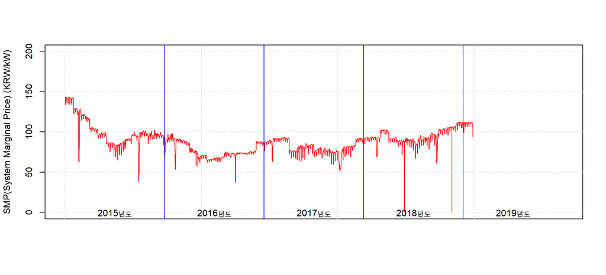

### **3. REC거래실적 분석**

```
[REC(신재생에너지 공급인증서,Renewable Engrgy Credit)]
신재생에너지를 이용하여 에너지를 공급한 사실을 증명하는 인증서입니다. 실제 공급량에 가중치를 곱한 양을 공급량으로 하여 MWh 기준으로 발급됩니다.
```

#### **3.1 최근 REC 거래현황**

##### **[육지]**

| 거래일자 | 거래가격(원/REC) | 거래물량(REC) | 비 고 |
| --- | --- | --- | --- |
| 2019-01-29 | 76983 | 70152 |  |
| 2019-01-31 | 75941 | 33152 |  |

#### **3.2 월별 REC 거래현황 (2016년3월~현재)**

2016년 3월부터 현재까지 월별 평균 REC 단가 및 실적을 분석하였습니다.

##### **[육지]**

| year | 1 | 2 | 3 | 4 | 5 | 6 | 7 | 8 | 9 | 10 | 11 | 12 | avg |
| --- | --- | --- | --- | --- | --- | --- | --- | --- | --- | --- | --- | --- | --- |
| 2016 | NA | NA | 98108 | 107608 | 124271 | 119596 | 131125 | 135195 | 152518 | 171624 | 147787 | 168051 | 135588 |
| 2017 | 151514 | 141249 | 125720 | 125075 | 131045 | 128058 | 126803 | 127132 | 127327 | 127410 | 120781 | 103778 | 127991 |
| 2018 | 110119 | 110560 | 101068 | 108463 | 109849 | 107324 | 104553 | 97920 | 91073 | 79658 | 75652 | 78872 | 97926 |
| 2019 | 73706 | NaN | NaN | NaN | NaN | NaN | NaN | NaN | NaN | NaN | NaN | NaN | 73706 |
| avg | 111780 | 125904 | 108298 | 113715 | 121722 | 118326 | 120827 | 120082 | 123639 | 126230 | 114740 | 116900 | 118514 |

#### **3.3 REC 차수별 현황 (2016년3월~현재)**

2016년 3월부터 현재까지 REC의 차수별 거래단가와 거래량에 대한 Trend를 분석하였습니다.

##### **[육지]**

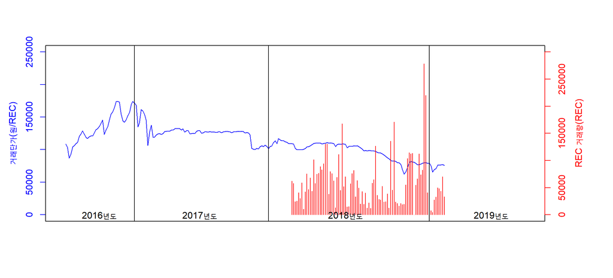

### **4. 공급인증서 발급대상 설비기준**

```
[REC 가중치]
산업통산자원부가 정책의 방향, 환경영향, 온실가스 배출 저감, 발전원가, 기술개발 및 산업활성화에 미치는 영향 등을 고려하여 효율적 발전 등에 이점이 있는 발전소에 혜택을 주는 방식으로 원칙적으로 REC가중치는 3년마다 갱신됩니다.
아래의 공급인증서 발급대상 설비기준은 2018년 6월 29일 개정된 내용을 기준으로 정리하였습니다.
```

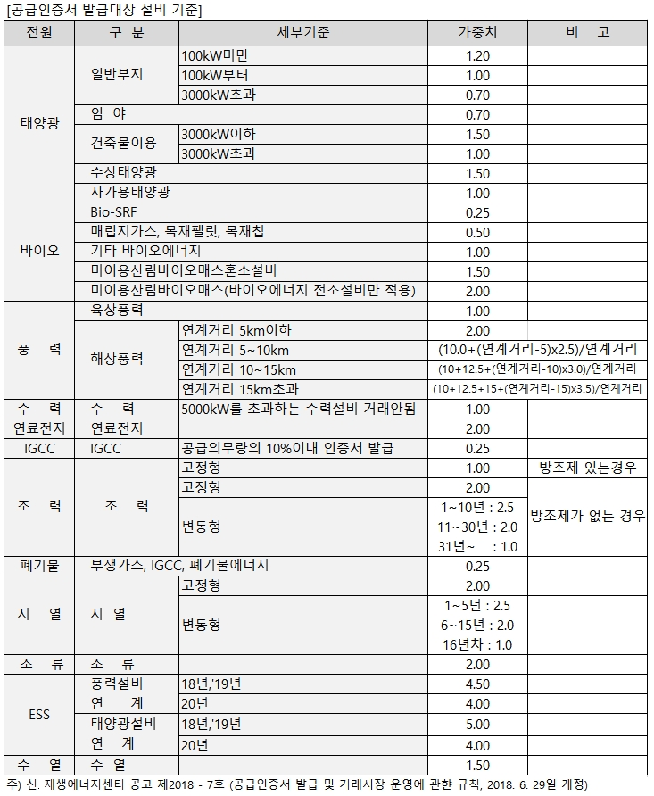

### **5. 국제유가 동향**

```
국제유가 동향은 한국석유공사의 국제유가 현황을 참고하여 DUBAI/WTI/BRENT유를 기준으로 작성하였습니다.
```

#### **5.1 국제유가 (2019-02-01)**

| 구 분 | DUBAI | WTI (NYMEX) | BRENT (ICE) |
| --- | --- | --- | --- |
| 국제유가($/bbl) | 60.87 | 55.26 | 62.75 |

#### **5.2 국제유가 TREND (2019년 1월~현재)**

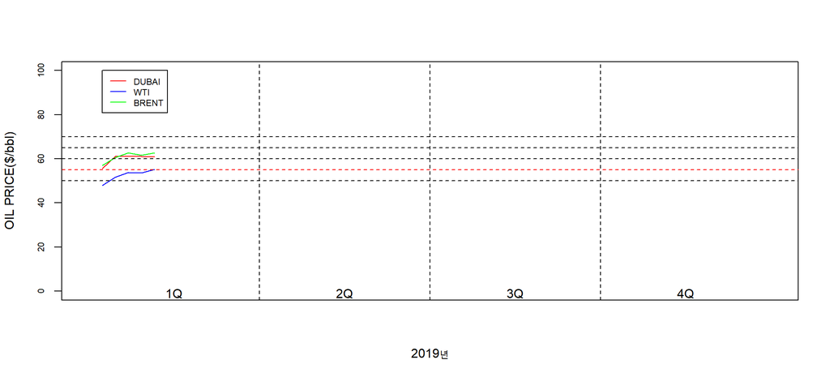